### Model dynamics

In this section, model dynamics will be examined. The first subsection will build a base model to use as a benchmark and examine what steady state populations these initial parameters generate. Subsequent subsections will examine various parameter perturbations against this baseline model in order to explore the dynamics of the model.

#### Base model

The base model relies upon arbitrarily chosen parameter values.

```r
source('sensitivity_analysis.R')

params <- reset.params()
params$c  # matrix of costs for moving from region i (row) to j (col)
```

```
##      [,1] [,2] [,3] [,4]
## [1,]    0  200  400  600
## [2,]  200    0  200  400
## [3,]  400  200    0  200
## [4,]  600  400  200    0
```

Initial utility is:

```r
params$k - params$p
```

```
## [1] 2021 1253 1426 1765
```

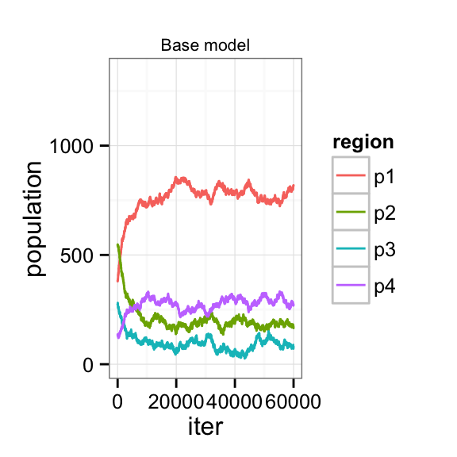

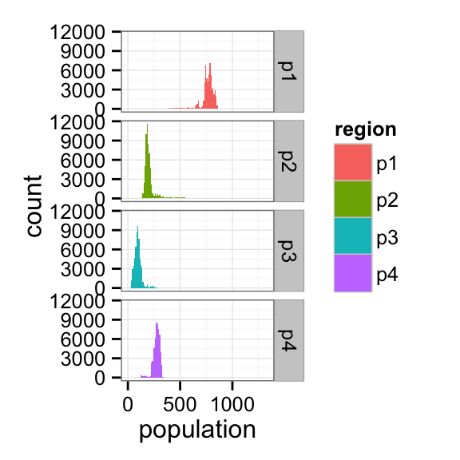

```
##  region  pop.mean ss.utility change.in.utility
##      p1 782.66826   1617.332         -403.6683
##      p2 186.73034   1613.270          360.2697
##      p3  85.96752   1614.032          188.0325
##      p4 279.63388   1620.366         -144.6339
```

We see that the populations converge after roughly 10,000 iterations, with relative stability across the different regions beyond that point. In the case of region 1, the population appears to converge to a steady state population of roughly 800. Region 2, 3, and 4 converge to equilibrium populations of roughly 200, 100, and 300, respectively. Steady state utilities across regions do not vary by much.

#### Initial conditions

Now that a base model has been run and examined, it is possible to explore whether its results are robust to changes in initial conditions. In the base model, the initial populations are 379, 547, 274, 135 for regions 1-4, respectively. Suppose the initial populations are instead, 0, 0, 0, 1335.

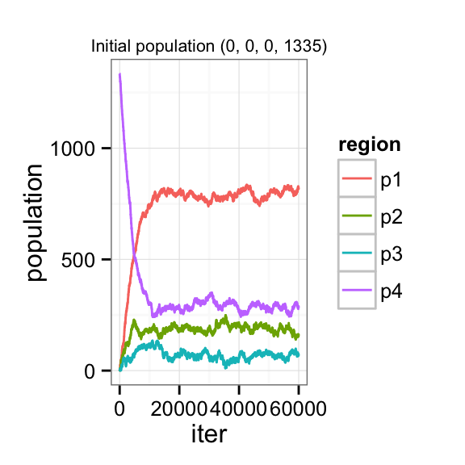

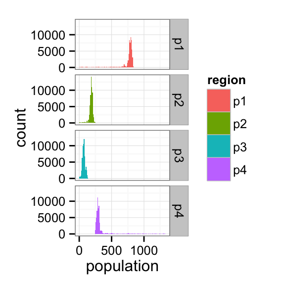

```
##  region  pop.mean ss.utility change.in.utility
##      p1 790.34054   1609.659         -411.3405
##      p2 188.54108   1611.459          358.4589
##      p3  68.79774   1631.202          205.2023
##      p4 287.32064   1612.679         -152.3206
```

The steady state populations and utilities are remarkably similar to the base model.

Suppose the population is split evenly between regions 1 and 4.

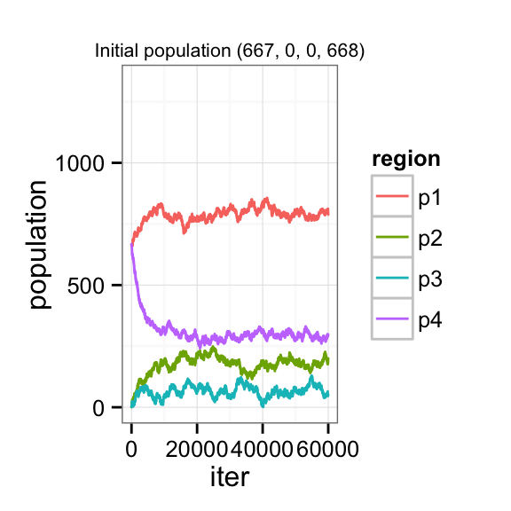

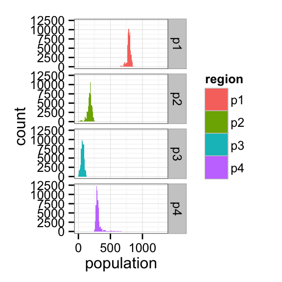

```
##  region  pop.mean ss.utility change.in.utility
##      p1 790.22182   1609.778        -123.22182
##      p2 183.76692   1616.233        -183.76692
##      p3  68.31264   1631.687         -68.31264
##      p4 292.69862   1607.301         375.30138
```

Once again, the population in each region quickly converges to the same steady state values as in the base model. We conclude that the steady state values are stable.

#### Cost of moving

Since the decision to move from one region to the other is a function of the utilities at both the source and destination regions, and cost, changing the cost of moving should directly impact the steady state populations. Specifically, the steady state population of a region should increase with cost out of that region and decrease with cost into that region.

If costs are increased for all moves into a region, fewer people will move into that region in steady state since the increased cost will effectively eat into the utility differential between the two regions. Simulation confirms this intuition.

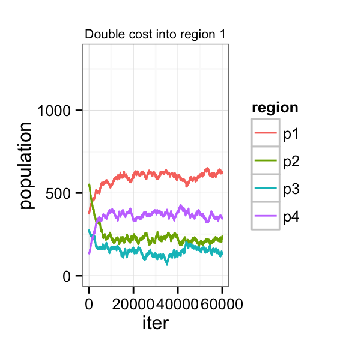

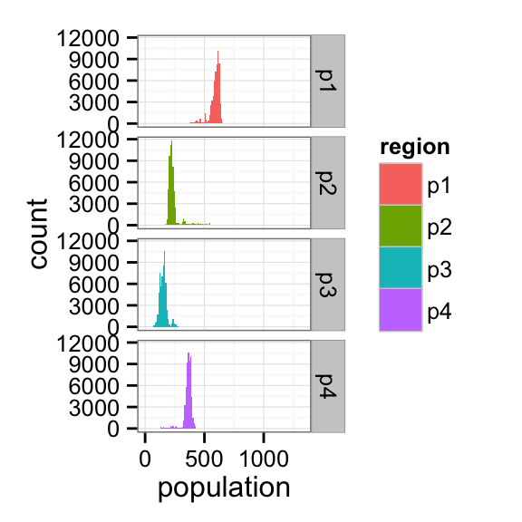

```
##  region pop.mean ss.utility change.in.utility
##      p1 603.4346   1796.565         -224.4346
##      p2 218.5966   1581.403          328.4034
##      p3 143.6570   1556.343          130.3430
##      p4 369.3118   1530.688         -234.3118
```

A similar reasoning applies to costs for moving out a region, implying that fewer people will move out in equilibrium. Once again, simulation is in line with expectations.

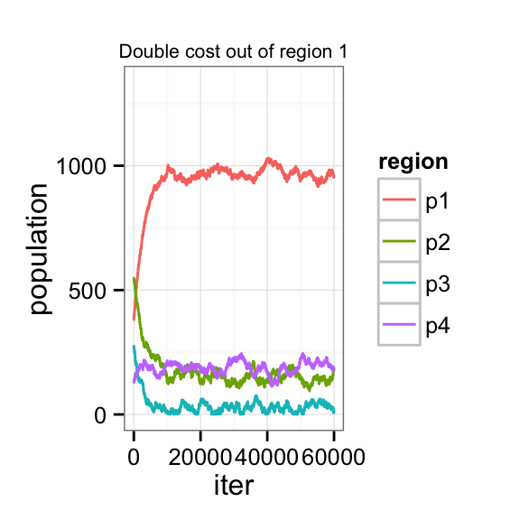

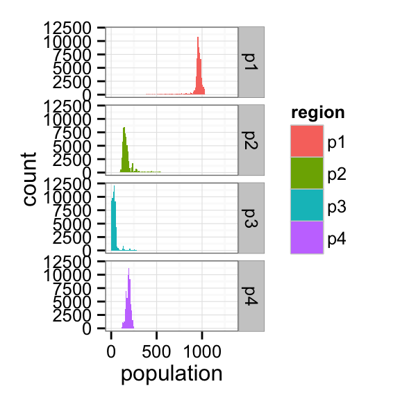

```
##  region pop.mean ss.utility change.in.utility
##      p1 968.0054   1431.995        -589.00540
##      p2 150.3948   1649.605         396.60516
##      p3  27.2799   1672.720         246.72010
##      p4 189.3199   1710.680         -54.31986
```

An interesting case is when costs are increased proportionally across all pairwise moves. We would expect that if costs are high enough, no moves will take place and the steady state will be the initial populations. For smaller increases, it is less clear: relative attractiveness among regions remains unchanged from the base case, but how steady state populations are affected is not immediately evident.

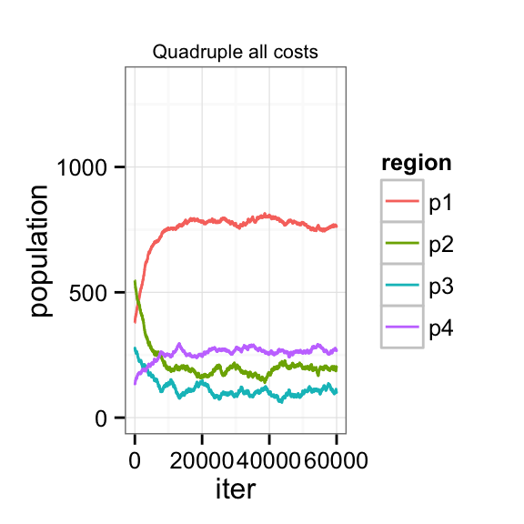

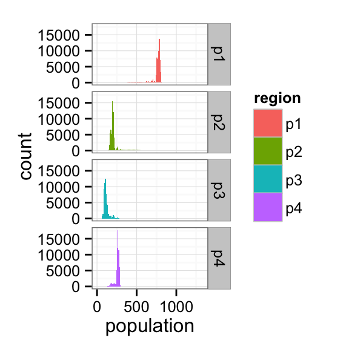

```
##  region pop.mean ss.utility change.in.utility
##      p1 776.8314   1623.169         -397.8314
##      p2 189.6409   1610.359          357.3591
##      p3 102.9186   1597.081          171.0814
##      p4 265.6091   1634.391         -130.6091
```

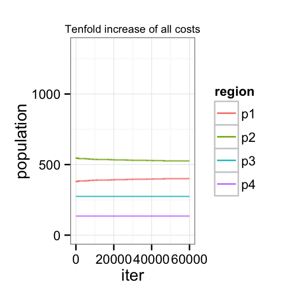

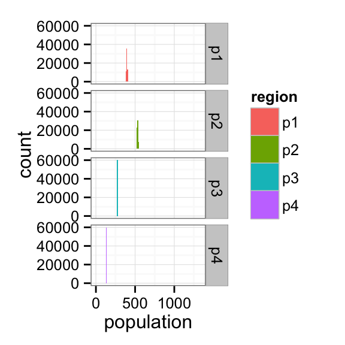

It appears that when costs quadruple, steady state populations do not change noticeably. Convergence appears to suffer, as the acceptance condition in the Metropolis-Hastings algorithm rejects more proposed moves. With a tenfold proportional increase in costs, we see hardly any movement from the starting conditions, as we would expect when costs are extremely high.

#### Utility

The base model computes the utility in the form of $u_i = k_i - p_i$, where $k_1 = 2400$, $k_2 = 1800$, $k_3 = 1700$, and $k_4 = 1900$.

Decreasing $k_1$ to 2000, we would expect the steady state population of region 1 to decrease and the populations of region 2, 3, and 4 to increase.

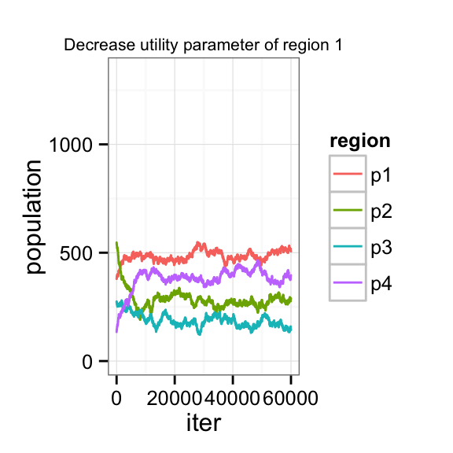

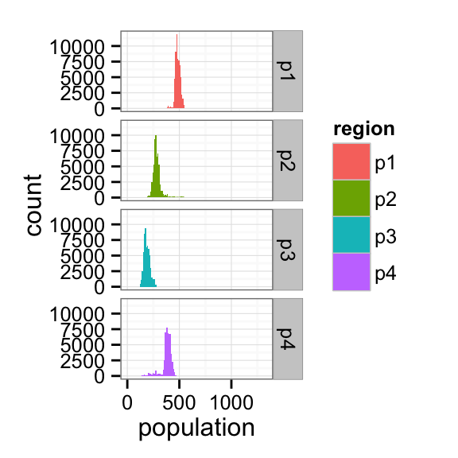

```
##  region pop.mean ss.utility change.in.utility
##      p1 487.1371   1512.863        -108.13712
##      p2 276.6275   1523.372         270.37248
##      p3 178.7314   1521.269          95.26864
##      p4 392.5040   1507.496        -257.50400
```

As expected, the steady state population of region 1 is much smaller, at just below 500.

What would happen if the $k$ parameter is equal across all regions? The steady state populations will be roughly equal to each other.

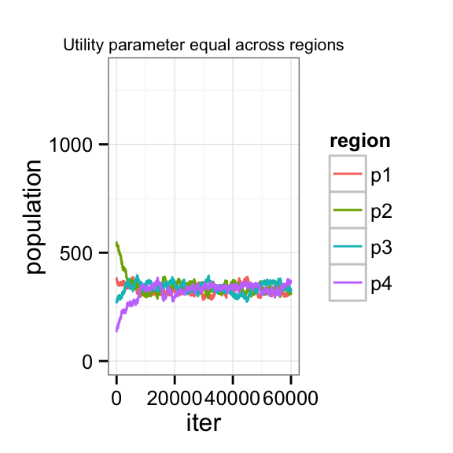

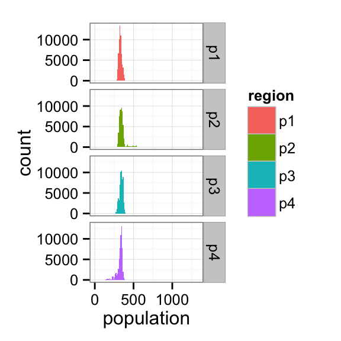

```
##  region pop.mean ss.utility change.in.utility
##      p1 325.4230   1624.577          53.57700
##      p2 336.3462   1613.654         210.65382
##      p3 338.7825   1611.217         -64.78252
##      p4 334.4483   1615.552        -199.44830
```

As the graphic above clearly demonstrates, the steady state utility levels and populations are approximately equal.

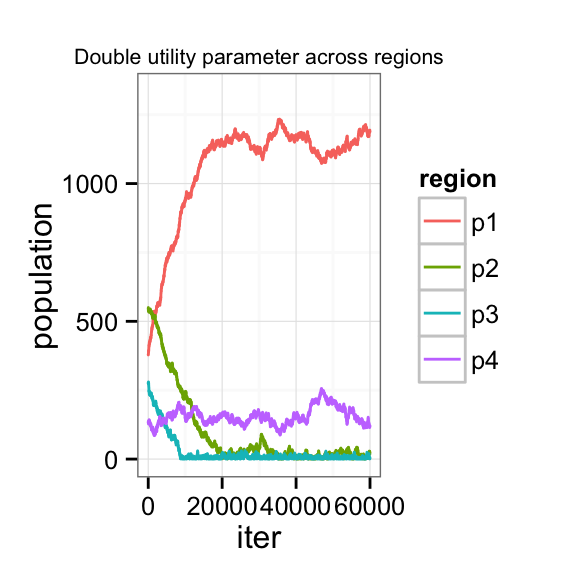

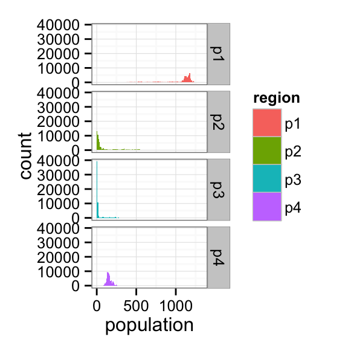

```
##  region   pop.mean ss.utility change.in.utility
##      p1 1135.71000   3664.290        -756.71000
##      p2   35.84690   3564.153         511.15310
##      p3    6.66818   3393.332         267.33182
##      p4  156.77492   3643.225         -21.77492
```